**Google Colab Guide**

by Prof. Seungchul Lee  
http://iai.postech.ac.kr/  
Industrial AI Lab at POSTECH

Table of Contents

# 1. Overview

- Access to GoogleColab
- GPU Settings
  - Colab enables users to use GPU
- Synchronization with GoogleDrive
  - It should be synchronized with GoogleDrive while the data being used from the loading
  - No needed when implementing codes without loading data
- References
  - https://zzsza.github.io/data/2018/08/30/google-colab/#%EA%B5%AC%EA%B8%80-%EB%93%9C%EB%9D%BC%EC%9D%B4%EB%B8%8C%EC%99%80-colab-%EC%97%B0%EB%8F%99

```python
%%html
<center><iframe src="https://www.youtube.com/embed/inN8seMm7UI?rel=0"
width="560" height="315" frameborder="0" allowfullscreen></iframe></center>
```

[video not shown]

```python
%%html
<center><iframe src="https://www.youtube.com/embed/PitcORQSjNM?rel=0"
width="560" height="315" frameborder="0" allowfullscreen></iframe></center>
```

[video not shown]

# 2. Requirement

- You might need to have google account for Colab
- Owing to its remote access, there are no particular computing specifications.
- Saving the work regularly prevents the kernel from disconnecting on long-time work

# 3. Connect and Create New Notebook

- Search for 'Colab' in google's search window and access to the site (https://colab.research.google.com/) shown as the figure below

[figure not shown]

- You'll be able to create ipynb file by clicking NEW PYTHON 3 NOTEBOOK in the right below at main page
  - Every ipynb file would be saved in GoogleDrvie even if it's not synchronized to it.

[figure not shown]

# 4. GPU Setting

- Tesla K80 12GB available for free
- Available 12 hours in a row and automatically disconnected if there is no response 90 mintues later
  - Not meaning the 12-hour regulation in a day but meaning the 12-hour sequential limitation
- Select Runtime -> Change runtime type in the left above

[figure not shown]

- Click Hardware accelerate, select GPU and save it

[figure not shown]

# 5. Mounting Your Google Drive

- Synchronization makes it easier to use the data on GoogleDrive
- Type the code as above and implement it

```python
from google.colab import auth
auth.authenticate_user()

from google.colab import drive
drive.mount('/content/gdrive')
```

[figure not shown]

- Login with user's own google account and allow after clicking the link

[figure not shown]

- Copy the code

[figure not shown]

- Paste the code to the window and enter it

[figure not shown]

- The message as the figure above will be shown if it works nomarlly

[figure not shown]

- Please refer to the materials for more information

# 6. Google Drive Path

- your google drive path: /content/gdrive/My Drive/
- colab notebook path: /content/gdrive/My Drive/Colab Notebooks

Please refer to the below figure.

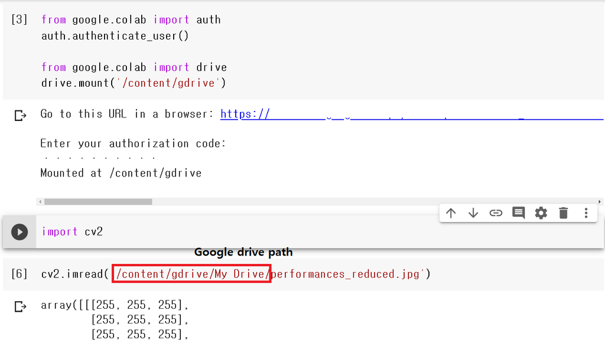

[figure not shown]

```python
%%javascript
$.getScript('https://kmahelona.github.io/ipython_notebook_goodies/ipython_notebook_toc.js')
```